# sanfransisco-tree

# Predict which trees are maintained by the San Fransisco Department of Public Works.

Inspired by Julia Silge

```r
library(tidyverse)
theme_set(theme_light())
sf_trees <- readr::read_csv('https://raw.githubusercontent.com/rfordatascience/tidytuesday/master/data/2020/2020-01-28/sf_trees.csv')
```

- use parse_number() to get a rough estimate of the size of the plot from the plot_size column.
- keep only observations with no NA values.

```r
trees_df <- sf_trees %>%
  mutate(legal_status = case_when(
    legal_status == "DPW Maintained" ~ legal_status,
    TRUE ~ "Other"
  ),
  plot_size = parse_number(plot_size)) %>%
  select(-address) %>%
  na.omit() %>%
  mutate_if(is.character, factor)
```

# How are these trees distributed across SF?

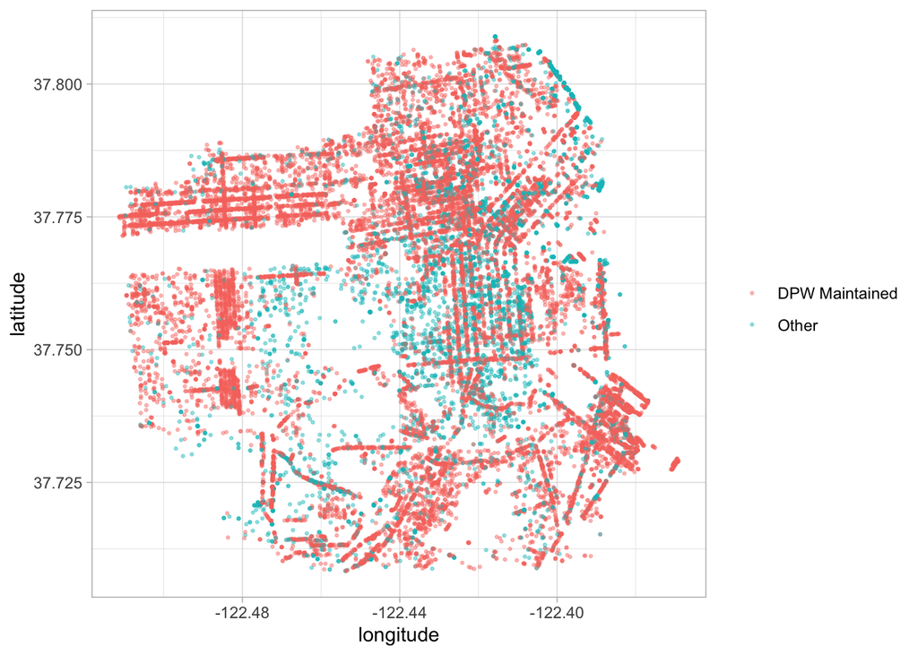

```r
trees_df %>%
  ggplot(aes(longitude, latitude, color = legal_status)) +
  geom_point(size = 0.5, alpha = 0.4) +
  labs(color = NULL)
```

Prelim observation: Spatial differences by category, but not so obvious how these are categorised.

# How about the relationships with the caretaker of each tree?

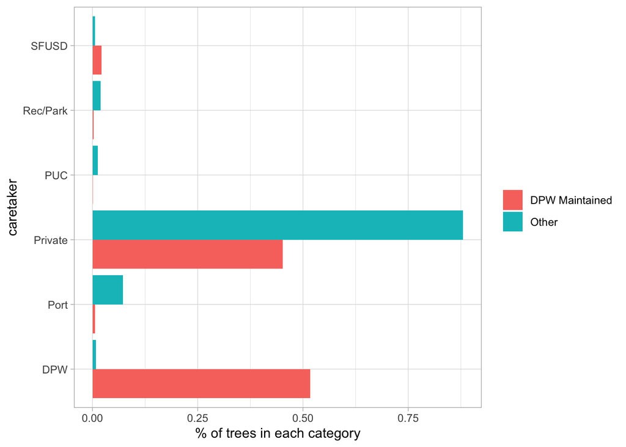

```r
trees_df %>%
  count(legal_status, caretaker) %>%
  add_count(caretaker, wt = n, name = "caretaker_count") %>%
  filter(caretaker_count > 50) %>%
  group_by(legal_status) %>%
  mutate(percent_legal = n / sum(n)) %>%
  ggplot(aes(percent_legal, caretaker, fill = legal_status)) +
  geom_col(position = "dodge") +
  labs(fill = NULL,
       x = "% of trees in each category")
```

# Build model

```r
library(tidymodels)
set.seed(123)
trees_split <- initial_split(trees_df, strata = legal_status)
trees_train <- training(trees_split)
trees_test <- testing(trees_split)
```

We’ll now build a recipe for data preprocessing. - First, we must tell the recipe() what our model is going to be (using a formula here) and what our training data is. - Next, we update the role for tree_id, since this is a varibale we might like to keep around for convenience as an identifier for rows but is not a predictor or outcome. - Next, we use step_other() to collapse categorical levels for species, caretaker, and the site info. Before this step, there were 300+ species! - The date column with when each tree was planted may be useful for fitting this model, but probably not the date, and then remove the original date variable. - There are many more DPW maintained trees than not, so let’s downsample the data for training.

The object tree_rec is a recipe that has not been trained on data yet (for eg, which categorical levels should be collapsed has not been calculated) and tree_prep is an object that has been trained on data.

```r
tree_rec <- recipe(legal_status ~ ., data = trees_train) %>%
  update_role(tree_id, new_role = "ID") %>% # convert tree_id column into just ID and won't be included in the model
  step_other(species, caretaker, threshold = 0.01) %>% # can consider tuning threshold for step_other
  step_other(site_info, threshold = 0.005) %>%
  step_dummy(all_nominal(), -all_outcomes()) %>%
  step_date(date, features = c("year")) %>%
  step_rm(date) %>%
  step_downsample(legal_status)

tree_prep <- prep(tree_rec)
juiced <- juice(tree_prep)
```

Now it’s time to create a model specification for a random forest where we will tune mtry(the number of predictors to sample at each split) and min_n (the number of observations needed to keep splitting nodes). These are hyperparameters that can’t be learned from data when training the model.

```r
tune_spec <- rand_forest(
  mtry = tune(),
  trees = 1000,
  min_n = tune()) %>%
  set_mode("classification") %>%
  set_engine("ranger")
```

We use workflow(), which is a convenience contained object for carrying around bits of models.

```r
tune_wf <- workflow() %>%
  add_recipe(tree_rec) %>%
  add_model(tune_spec)
```

# Train hyperparameters

- Create a set of cross-validation resamples to use for tuning

```r
set.seed(234)
trees_folds <- vfold_cv(trees_train, v = 5)
```

- Use parallel processing to train a whole bunch of models

```r
doParallel::registerDoParallel()

set.seed(345)
tune_res <- tune_grid(
  tune_wf,
  resamples = trees_folds,
  grid = 10
)

tune_res
```

```
## #  5-fold cross-validation
## # A tibble: 5 x 4
##   splits               id    .metrics          .notes
##   <list>               <chr> <list>            <list>
## 1 <split [14.3K/3.6K]> Fold1 <tibble [20 × 5]> <tibble [0 × 1]>
## 2 <split [14.3K/3.6K]> Fold2 <tibble [20 × 5]> <tibble [0 × 1]>
## 3 <split [14.3K/3.6K]> Fold3 <tibble [20 × 5]> <tibble [0 × 1]>
## 4 <split [14.3K/3.6K]> Fold4 <tibble [20 × 5]> <tibble [0 × 1]>
## 5 <split [14.3K/3.6K]> Fold5 <tibble [20 × 5]> <tibble [0 × 1]>
```

- Visualize to get rough idea on the hyperparameter space

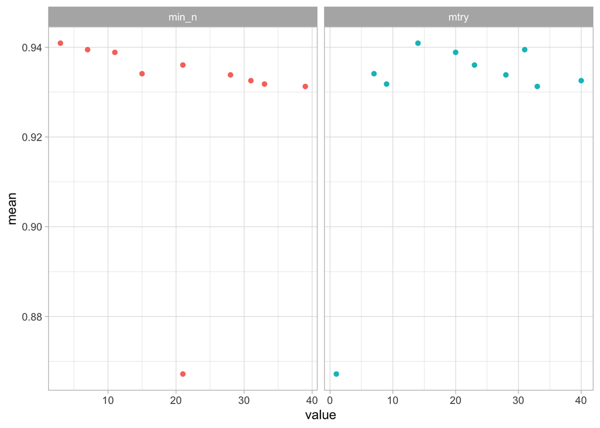

```r
tune_res %>%
  collect_metrics() %>%
  filter(.metric == "roc_auc") %>%
  select(mean, min_n, mtry) %>%
  pivot_longer(min_n:mtry,
               values_to = "value",
               names_to = "parameter") %>%
  ggplot(aes(value, mean, color = parameter)) +
  geom_point(show.legend = FALSE)+
  facet_wrap(~ parameter, scales = "free_x")
```

Higher values of mtry are good (> 10) and lower values of min_n are good (< 10). We can use regular_grid from a smaller space to improve our model. - Use a smaller hyperparameter space based on the previous results

```r
rf_grid <- grid_regular(
  mtry(range = c(10, 30)),
  min_n(range = c(2, 8)),
  levels = 5
)

set.seed(456)
regular_res <- tune_grid(
  tune_wf,
  resamples = trees_folds,
  grid = rf_grid
)

regular_res
```

```
## #  5-fold cross-validation
## # A tibble: 5 x 4
##   splits               id    .metrics          .notes
##   <list>               <chr> <list>            <list>
## 1 <split [14.3K/3.6K]> Fold1 <tibble [50 × 5]> <tibble [0 × 1]>
## 2 <split [14.3K/3.6K]> Fold2 <tibble [50 × 5]> <tibble [0 × 1]>
## 3 <split [14.3K/3.6K]> Fold3 <tibble [50 × 5]> <tibble [0 × 1]>
## 4 <split [14.3K/3.6K]> Fold4 <tibble [50 × 5]> <tibble [0 × 1]>
## 5 <split [14.3K/3.6K]> Fold5 <tibble [50 × 5]> <tibble [0 × 1]>
```

- Visualize to performance from regular grid

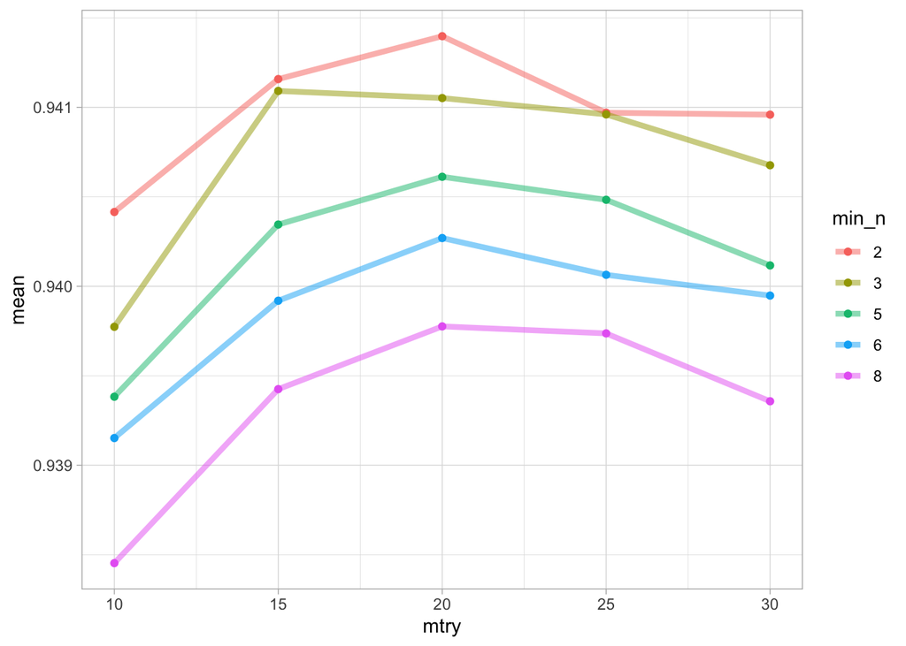

```r
regular_res %>%
  collect_metrics() %>%
  filter(.metric == "roc_auc") %>%
  mutate(min_n = factor(min_n)) %>%
  ggplot(aes(mtry, mean, color = min_n)) +
  geom_line(alpha = 0.5, size = 1.5) +
  geom_point()
```

- Get the best hyperparameters based on ROC-AUC for our best model

```r
best_auc <- select_best(regular_res, "roc_auc")

final_rf <- finalize_model(
  tune_spec,
  best_auc
)
```

# Check features importance from the final model

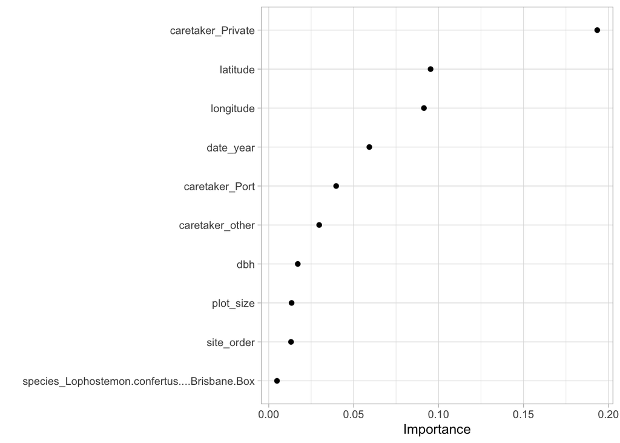

```r
library(vip)
final_rf %>%
  set_engine("ranger", importance = "permutation") %>%
  fit(legal_status ~.,
      data = juice(tree_prep) %>% select(-tree_id)) %>%
  vip(geom = "point")
```

The private caretaker characteristic is important in categorization, as is latitude and longitude. Interestingly, we also see year (i.e. age of the tree) has higher importance too. # Check the performance of this model on the test data

```r
final_wf <- workflow() %>%
  add_recipe(tree_rec) %>%
  add_model(final_rf)

final_res <- final_wf %>%
  last_fit(trees_split)

final_res %>%
  collect_metrics()
```

```
## # A tibble: 2 x 3
##   .metric  .estimator .estimate
##   <chr>    <chr>          <dbl>
## 1 accuracy binary         0.851
## 2 roc_auc  binary         0.945
```

The metrics fr the test set look good and indicate that our model didn’t overfit during hyperparameter tuning.

- Check predictions and visualize in the map to see where our model works well. This allows us to inspect the model and location further

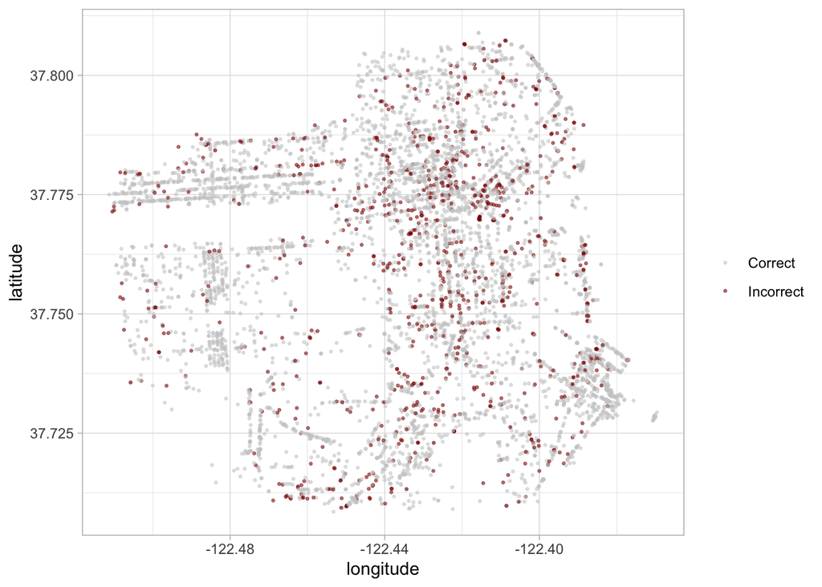

```r
final_res %>%
  collect_predictions() %>%
  mutate(correct = case_when(legal_status == .pred_class ~ "Correct",
                             TRUE ~ "Incorrect")) %>%
  bind_cols(trees_test) %>%
  ggplot(aes(longitude, latitude, color = correct)) +
  geom_point(size = 0.5, alpha = 0.5) +
  labs(color = NULL) +
  scale_color_manual(values = c("gray80", "darkred"))
```